# py_sklearn_binaryclass_kaggle_tabular_playground_2021sep

### Binary Classification Model for Kaggle Tabular Playground Series September 2021 Using Python and Scikit-Learn

### October 18, 2021

Template Credit: Adapted from a template made available by Dr. Jason Brownlee of Machine Learning Mastery. [https://machinelearningmastery.com/]

SUMMARY: This project aims to construct a predictive model using various machine learning algorithms and document the end-to-end steps using a template. The Kaggle Tabular Playground September 2021 dataset is a binary classification situation where we attempt to predict one of the two possible outcomes.

INTRODUCTION: Kaggle wants to provide an approachable environment for relatively new people in their data science journey. Since January 2021, they have hosted playground-style competitions on Kaggle with fun but less complex, tabular datasets. The dataset used for this competition is synthetic but based on a real dataset and generated using a CTGAN. The original dataset deals with predicting whether a customer will file a claim on an insurance policy. Although the features are anonymized, they have properties relating to real-world features.

ANALYSIS: The average performance of the machine learning algorithms achieved a ROC/AUC benchmark of 0.6214 using the training dataset. We selected Random Forest as the final model as it processed the training dataset with a final ROC/AUC score of 0.7361. When we processed Kaggle's test dataset with the final model, the model achieved a ROC/AUC score of 0.7372.

Dataset Used: Kaggle Tabular Playground 2021 September Data Set

Dataset Reference: https://www.kaggle.com/c/tabular-playground-series-sep-2021

One potential source of performance benchmark: https://www.kaggle.com/c/tabular-playground-series-sep-2021/leaderboard

Any predictive modeling machine learning project generally can be broken down into about six major tasks:

1. Prepare Environment
2. Summarize and Visualize Data
3. Pre-process Data
4. Train and Evaluate Models
5. Fine-tune and Improve Models
6. Finalize Model and Present Analysis

## Task 1 - Prepare Environment

```python
# Install the necessary packages for Colab
# !pip install python-dotenv PyMySQL
```

```python
# Retrieve the GPU information from Colab
# gpu_info = !nvidia-smi
# gpu_info = '\n'.join(gpu_info)
# if gpu_info.find('failed') >= 0:
#     print('Select the Runtime → "Change runtime type" menu to enable a GPU accelerator, ')
#     print('and then re-execute this cell.')
# else:
#     print(gpu_info)
```

```python
# Retrieve the memory configuration from Colab
# from psutil import virtual_memory
# ram_gb = virtual_memory().total / 1e9
# print('Your runtime has {:.1f} gigabytes of available RAM\n'.format(ram_gb))

# if ram_gb < 20:
#     print('To enable a high-RAM runtime, select the Runtime → "Change runtime type"')
#     print('menu, and then select High-RAM in the Runtime shape dropdown. Then, ')
#     print('re-execute this cell.')
# else:
#     print('You are using a high-RAM runtime!')
```

```python
# Retrieve the CPU information
ncpu = !nproc
print("The number of available CPUs is:", ncpu[0])
```

```
The number of available CPUs is: 4
```

### 1.a) Load libraries and modules

```python
# Set the random seed number for reproducible results
RNG_SEED = 888
```

```python
import numpy as np
import pandas as pd
import seaborn as sns
import matplotlib.pyplot as plt
import os
import sys
import math
from datetime import datetime
# import boto3
# from dotenv import load_dotenv
from sklearn import preprocessing
from sklearn.model_selection import train_test_split
from sklearn.model_selection import StratifiedKFold
from sklearn.model_selection import cross_val_score
from sklearn.model_selection import GridSearchCV
from sklearn.metrics import classification_report
from sklearn.metrics import confusion_matrix
from sklearn.metrics import accuracy_score
from sklearn.metrics import roc_auc_score
from sklearn.pipeline import Pipeline
from sklearn import compose
from sklearn import impute

from sklearn.linear_model import LogisticRegression
from sklearn.tree import DecisionTreeClassifier
from sklearn.neighbors import KNeighborsClassifier
from sklearn.ensemble import BaggingClassifier
from sklearn.ensemble import RandomForestClassifier
from sklearn.ensemble import ExtraTreesClassifier
from sklearn.ensemble import GradientBoostingClassifier
```

### 1.b) Set up the controlling parameters and functions

```python
# Begin the timer for the script processing
start_time_script = datetime.now()

# Set up the number of CPU cores available for multi-thread processing
N_JOBS = 1

# Set up the flag to stop sending progress emails (setting to True will send status emails!)
NOTIFY_STATUS = False

# Set the percentage sizes for splitting the dataset
TEST_SET_RATIO = 0.2
VAL_SET_RATIO = 0.25

# Set the number of folds for cross validation
N_FOLDS = 5

# Set various default modeling parameters
SCORING_METRIC = 'roc_auc'
```

```python
# Set up the email notification function
def status_notify(msg_text):
    access_key = os.environ.get('SNS_ACCESS_KEY')
    secret_key = os.environ.get('SNS_SECRET_KEY')
    aws_region = os.environ.get('SNS_AWS_REGION')
    topic_arn = os.environ.get('SNS_TOPIC_ARN')
    if (access_key is None) or (secret_key is None) or (aws_region is None):
        sys.exit("Incomplete notification setup info. Script Processing Aborted!!!")
    sns = boto3.client('sns', aws_access_key_id=access_key, aws_secret_access_key=secret_key, region_name=aws_region)
    response = sns.publish(TopicArn=topic_arn, Message=msg_text)
    if response['ResponseMetadata']['HTTPStatusCode'] != 200 :
        print('Status notification not OK with HTTP status code:', response['ResponseMetadata']['HTTPStatusCode'])
```

```python
if NOTIFY_STATUS: status_notify("Task 1 - Prepare Environment has begun! " + datetime.now().strftime('%a %B %d, %Y %I:%M:%S %p'))
```

### 1.c) Load dataset

```python
dataset_path = 'https://dainesanalytics.com/datasets/kaggle-tabular-playground-2021sep/train.csv'
df_dataset_import = pd.read_csv(dataset_path, index_col=False)

# Take a peek at the dataframe after import
print(df_dataset_import.head())
```

```
   id       f1        f2         f3        f4       f5        f6       f7  \
0   0  0.10859  0.004314    -37.566  0.017364  0.28915 -10.25100   135.12
1   1  0.10090  0.299610  11822.000  0.276500  0.45970  -0.83733  1721.90
2   2  0.17803 -0.006980    907.270  0.272140  0.45948   0.17327  2298.00
3   3  0.15236  0.007259    780.100  0.025179  0.51947   7.49140   112.51
4   4  0.11623  0.502900   -109.150  0.297910  0.34490  -0.40932  2538.90

         f8            f9  ...     f110    f111     f112      f113      f114  \
0  168900.0  3.992400e+14  ... -12.2280  1.7482  1.90960  -7.11570   4378.80
1  119810.0  3.874100e+15  ... -56.7580  4.1684  0.34808   4.14200    913.23
2  360650.0  1.224500e+13  ...  -5.7688  1.2042  0.26290   8.13120  45119.00
3  259490.0  7.781400e+13  ... -34.8580  2.0694  0.79631 -16.33600   4952.40
4   65332.0  1.907200e+15  ... -13.6410  1.5298  1.14640  -0.43124   3856.50

     f115          f116    f117     f118  claim
0  1.2096  8.613400e+14   140.1  1.01770      1
1  1.2464  7.575100e+15  1861.0  0.28359      0
2  1.1764  3.218100e+14  3838.2  0.40690      1
3  1.1784  4.533000e+12  4889.1  0.51486      1
4  1.4830 -8.991300e+12     NaN  0.23049      1

[5 rows x 120 columns]
```

```python
df_dataset_import.info(verbose=True)
```

```
<class 'pandas.core.frame.DataFrame'>
RangeIndex: 957919 entries, 0 to 957918
Data columns (total 120 columns):
 #    Column  Dtype
---   ------  -----
 0    id      int64
 1    f1      float64
 2    f2      float64
 3    f3      float64
 4    f4      float64
 5    f5      float64
 6    f6      float64
 7    f7      float64
 8    f8      float64
 9    f9      float64
```

[output cut: 112 more lines]

```python
print(df_dataset_import.describe())
```

```
                  id             f1             f2             f3  \
count  957919.000000  942672.000000  942729.000000  942428.000000
mean   478959.000000       0.090201       0.345964    4068.744207
std    276527.540593       0.043564       0.146251    6415.829440
min         0.000000      -0.149910      -0.019044   -9421.700000
25%    239479.500000       0.070227       0.283050     418.430000
50%    478959.000000       0.090135       0.389100    1279.500000
75%    718438.500000       0.116500       0.458450    4444.400000
max    957918.000000       0.415170       0.518990   39544.000000

                  f4             f5             f6             f7  \
count  942359.000000  942514.000000  942398.000000  942415.000000
mean        0.201214       0.304869      -0.071458    1620.843815
std         0.212510       0.145343       2.123777    1276.281403
min        -0.082122      -0.006990     -12.791000    -224.800000
25%         0.035086       0.240520      -1.120700     481.545000
50%         0.137000       0.327790      -0.380110    1446.100000
75%         0.297100       0.412830       0.921940    2495.900000
max         1.319900       0.554750      11.202000    5426.600000

                 f8            f9  ...           f110           f111  \
count  9.425460e+05  9.426700e+05  ...  942554.000000  942420.000000
mean   3.771642e+05  1.806054e+15  ...     -19.926398       2.074530
std    3.454325e+05  2.335204e+15  ...      18.578439       0.895793
min   -2.984300e+04 -1.153300e+15  ...    -105.860000       0.277040
25%    9.120900e+04  1.153100e+13  ...     -28.812000       1.487700
50%    2.896700e+05  5.043050e+14  ...     -14.636000       1.662100
75%    5.605600e+05  3.103100e+15  ...      -5.325300       2.522325
max    1.913700e+06  1.042400e+16  ...       1.613400       4.565900

                f112           f113           f114           f115  \
count  942509.000000  942686.000000  942481.000000  942360.000000
mean       23.885245       1.748777   63152.973540       1.208876
std        45.581360      10.088848   92435.016241       0.114959
min       -27.691000     -26.589000  -81977.000000       0.905270
25%        -0.628880      -4.473975    2443.200000       1.146800
50%         1.727700       0.885710   19479.000000       1.177200
75%        18.991000       6.840775   88488.000000       1.242000
max       217.840000      47.757000  526050.000000       1.886700

               f116           f117           f118          claim
count  9.423300e+05  942512.000000  942707.000000  957919.000000
mean   4.276905e+16    3959.204669       0.559267       0.498492
std    6.732441e+16    3155.991777       0.408426       0.499998
min   -8.944400e+15    -415.240000      -0.151240       0.000000
25%    2.321100e+14    1306.200000       0.276560       0.000000
50%    1.327500e+16    3228.000000       0.473440       0.000000
75%    5.278700e+16    6137.900000       0.746210       1.000000
max    3.249900e+17   13151.000000       2.743600       1.000000

[8 rows x 120 columns]
```

```python
print(df_dataset_import.isnull().sum())
print('Total number of NaN in the dataframe: ', df_dataset_import.isnull().sum().sum())
```

```
id           0
f1       15247
f2       15190
f3       15491
f4       15560
         ...
f115     15559
f116     15589
f117     15407
f118     15212
claim        0
Length: 120, dtype: int64
Total number of NaN in the dataframe:  1820782
```

### 1.d) Data Cleaning

```python
# Dropping features
df_dataset_import.drop(columns=['id'], inplace=True)

# Standardize the class column to the name of target
df_dataset_import = df_dataset_import.rename(columns={'claim':'target'})

# Take a peek at the dataframe after cleaning
print(df_dataset_import.head())
```

```
        f1        f2         f3        f4       f5        f6       f7  \
0  0.10859  0.004314    -37.566  0.017364  0.28915 -10.25100   135.12
1  0.10090  0.299610  11822.000  0.276500  0.45970  -0.83733  1721.90
2  0.17803 -0.006980    907.270  0.272140  0.45948   0.17327  2298.00
3  0.15236  0.007259    780.100  0.025179  0.51947   7.49140   112.51
4  0.11623  0.502900   -109.150  0.297910  0.34490  -0.40932  2538.90

         f8            f9        f10  ...     f110    f111     f112      f113  \
0  168900.0  3.992400e+14     86.489  ... -12.2280  1.7482  1.90960  -7.11570
1  119810.0  3.874100e+15   9953.600  ... -56.7580  4.1684  0.34808   4.14200
2  360650.0  1.224500e+13  15827.000  ...  -5.7688  1.2042  0.26290   8.13120
3  259490.0  7.781400e+13    -36.837  ... -34.8580  2.0694  0.79631 -16.33600
4   65332.0  1.907200e+15    144.120  ... -13.6410  1.5298  1.14640  -0.43124

       f114    f115          f116    f117     f118  target
0   4378.80  1.2096  8.613400e+14   140.1  1.01770       1
1    913.23  1.2464  7.575100e+15  1861.0  0.28359       0
2  45119.00  1.1764  3.218100e+14  3838.2  0.40690       1
3   4952.40  1.1784  4.533000e+12  4889.1  0.51486       1
4   3856.50  1.4830 -8.991300e+12     NaN  0.23049       1

[5 rows x 119 columns]
```

```python
df_dataset_import.info(verbose=True)
```

```
<class 'pandas.core.frame.DataFrame'>
RangeIndex: 957919 entries, 0 to 957918
Data columns (total 119 columns):
 #    Column  Dtype
---   ------  -----
 0    f1      float64
 1    f2      float64
 2    f3      float64
 3    f4      float64
 4    f5      float64
 5    f6      float64
 6    f7      float64
 7    f8      float64
 8    f9      float64
 9    f10     float64
```

[output cut: 111 more lines]

```python
print(df_dataset_import.describe())
```

```
                  f1             f2             f3             f4  \
count  942672.000000  942729.000000  942428.000000  942359.000000
mean        0.090201       0.345964    4068.744207       0.201214
std         0.043564       0.146251    6415.829440       0.212510
min        -0.149910      -0.019044   -9421.700000      -0.082122
25%         0.070227       0.283050     418.430000       0.035086
50%         0.090135       0.389100    1279.500000       0.137000
75%         0.116500       0.458450    4444.400000       0.297100
max         0.415170       0.518990   39544.000000       1.319900

                  f5             f6             f7            f8  \
count  942514.000000  942398.000000  942415.000000  9.425460e+05
mean        0.304869      -0.071458    1620.843815  3.771642e+05
std         0.145343       2.123777    1276.281403  3.454325e+05
min        -0.006990     -12.791000    -224.800000 -2.984300e+04
25%         0.240520      -1.120700     481.545000  9.120900e+04
50%         0.327790      -0.380110    1446.100000  2.896700e+05
75%         0.412830       0.921940    2495.900000  5.605600e+05
max         0.554750      11.202000    5426.600000  1.913700e+06

                 f9            f10  ...           f110           f111  \
count  9.426700e+05  942696.000000  ...  942554.000000  942420.000000
mean   1.806054e+15    5323.442367  ...     -19.926398       2.074530
std    2.335204e+15   10068.380032  ...      18.578439       0.895793
min   -1.153300e+15  -26404.000000  ...    -105.860000       0.277040
25%    1.153100e+13      75.876750  ...     -28.812000       1.487700
50%    5.043050e+14    1073.200000  ...     -14.636000       1.662100
75%    3.103100e+15    5693.200000  ...      -5.325300       2.522325
max    1.042400e+16   85622.000000  ...       1.613400       4.565900

                f112           f113           f114           f115  \
count  942509.000000  942686.000000  942481.000000  942360.000000
mean       23.885245       1.748777   63152.973540       1.208876
std        45.581360      10.088848   92435.016241       0.114959
min       -27.691000     -26.589000  -81977.000000       0.905270
25%        -0.628880      -4.473975    2443.200000       1.146800
50%         1.727700       0.885710   19479.000000       1.177200
75%        18.991000       6.840775   88488.000000       1.242000
max       217.840000      47.757000  526050.000000       1.886700

               f116           f117           f118         target
count  9.423300e+05  942512.000000  942707.000000  957919.000000
mean   4.276905e+16    3959.204669       0.559267       0.498492
std    6.732441e+16    3155.991777       0.408426       0.499998
min   -8.944400e+15    -415.240000      -0.151240       0.000000
25%    2.321100e+14    1306.200000       0.276560       0.000000
50%    1.327500e+16    3228.000000       0.473440       0.000000
75%    5.278700e+16    6137.900000       0.746210       1.000000
max    3.249900e+17   13151.000000       2.743600       1.000000

[8 rows x 119 columns]
```

```python
print(df_dataset_import.isnull().sum())
print('Total number of NaN in the dataframe: ', df_dataset_import.isnull().sum().sum())
```

```
f1        15247
f2        15190
f3        15491
f4        15560
f5        15405
          ...
f115      15559
f116      15589
f117      15407
f118      15212
target        0
Length: 119, dtype: int64
Total number of NaN in the dataframe:  1820782
```

### 1.e) Splitting Data into Sets

```python
# Use variable total_column_count to hold the number of columns in the dataframe
total_column_count = len(df_dataset_import.columns)

# Set up variable total_feature_count for the total number of attribute columns
total_feature_count = total_column_count-1

# We create attribute-only and target-only datasets (df_features_train and df_target_train)
df_target_train = df_dataset_import['target']
df_features_train = df_dataset_import.drop(['target'], axis=1)

print("df_dataset_import.shape: {} df_features_train.shape: {} df_target_train.shape: {}".format(df_dataset_import.shape, df_features_train.shape, df_target_train.shape))
```

```
df_dataset_import.shape: (957919, 119) df_features_train.shape: (957919, 118) df_target_train.shape: (957919,)
```

### 1.f) Set up the parameters for data visualization

```python
# Set up the number of row and columns for visualization display. display_rows * display_columns should be >= total_feature_count
display_columns = 4
if total_feature_count % display_columns == 0 :
    display_rows = total_feature_count // display_columns
else :
    display_rows = (total_feature_count // display_columns) + 1

# Set figure width to display the data visualization plots
fig_size = plt.rcParams["figure.figsize"]
fig_size[0] = display_columns * 4
fig_size[1] = display_rows * 4
plt.rcParams["figure.figsize"] = fig_size
```

```python
if NOTIFY_STATUS: status_notify("Task 1 - Prepare Environment completed! "+datetime.now().strftime('%a %B %d, %Y %I:%M:%S %p'))
```

## Task 2 - Summarize and Visualize Data

```python
if NOTIFY_STATUS: status_notify("Task 2 - Summarize and Visualize Data has begun! "+datetime.now().strftime('%a %B %d, %Y %I:%M:%S %p'))
```

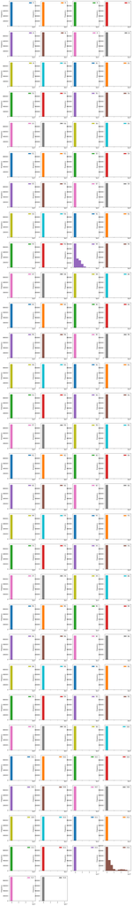

```python
# Histograms for each attribute
df_features_train.plot(kind='hist', subplots=True, layout=(display_rows, display_columns))
plt.show()
```

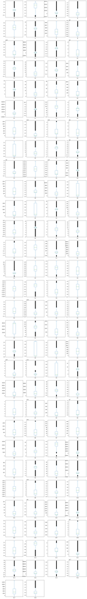

```python
# Box and Whisker plot for each attribute
df_features_train.plot(kind='box', subplots=True, layout=(display_rows, display_columns))
plt.show()
```

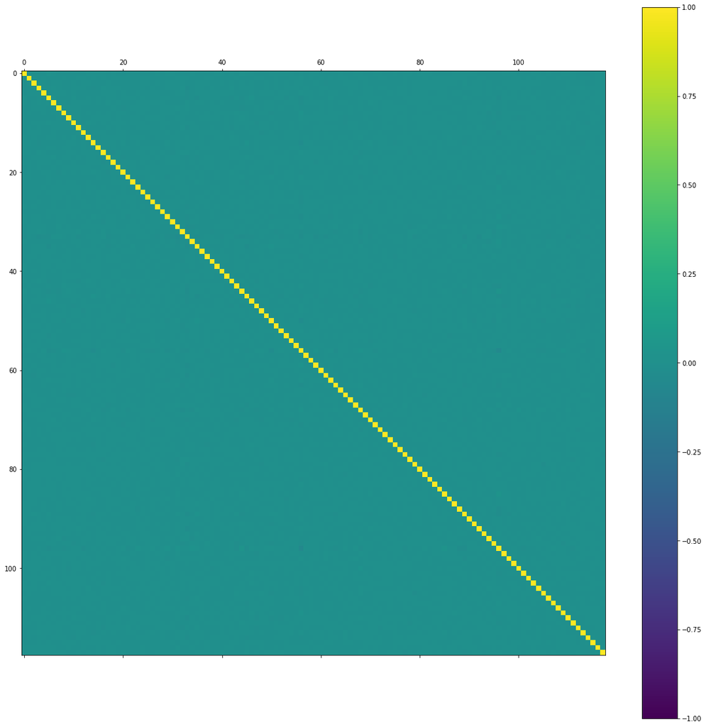

```python
# Correlation matrix
fig = plt.figure(figsize=(20,20))
ax = fig.add_subplot(111)
correlations = df_features_train.corr(method='pearson')
cax = ax.matshow(correlations, vmin=-1, vmax=1)
fig.colorbar(cax)
plt.show()
```

```python
if NOTIFY_STATUS: status_notify("Task 2 - Summarize and Visualize Data completed! "+datetime.now().strftime('%a %B %d, %Y %I:%M:%S %p'))
```

## Task 3 - Pre-process Data

```python
if NOTIFY_STATUS: status_notify("Task 3 - Pre-process Data has begun! "+datetime.now().strftime('%a %B %d, %Y %I:%M:%S %p'))
```

### 3.a) Splitting Data into Training and Test Sets

```python
# Not applicable for this iteration of the project
```

### 3.b) Feature Scaling and Data Pre-Processing

```python
# Compose pipeline for the numerical and categorical features (Block #1 of 2)
numeric_columns = df_features_train.select_dtypes(include=['int64','float64']).columns
numeric_transformer = Pipeline(steps=[
    ('imputer', impute.SimpleImputer(strategy="constant", fill_value=0)),
    ('scaler', preprocessing.MinMaxScaler())
])
categorical_columns = df_features_train.select_dtypes(include=['object','bool','category']).columns
categorical_transformer = Pipeline(steps=[
    ('imputer', impute.SimpleImputer(strategy='constant', fill_value='UKNOWN')),
    ('onehot', preprocessing.OneHotEncoder(sparse=False, handle_unknown='ignore'))
])

print("Number of numerical columns:", len(numeric_columns))
print("Number of categorical columns:", len(categorical_columns))
print("Total number of columns in the feature dataframe:", df_features_train.shape[1])
```

```
Number of numerical columns: 118
Number of categorical columns: 0
Total number of columns in the feature dataframe: 118
```

```python
# Compose pipeline for the numerical and categorical features (Block #2 of 2)
preprocessor = compose.ColumnTransformer(transformers=[
    ('num', numeric_transformer, numeric_columns),
    ('cat', categorical_transformer, categorical_columns)
])

# Display the shapes of the training dataset for final inspection
array_features_train = preprocessor.fit_transform(df_features_train)
print("Transformed features from df_features_train.shape: {} to array_features_train.shape: {}".format(df_features_train.shape, array_features_train.shape))
```

```
Transformed features from df_features_train.shape: (957919, 118) to array_features_train.shape: (957919, 118)
```

### 3.c) Training Data Balancing

```python
# Not applicable for this iteration of the project
```

### 3.d) Feature Selection

```python
# Not applicable for this iteration of the project
```

### 3.e) Display the Final Datasets for Model-Building

```python
# Finalize the training and validation datasets for the modeling activities
# array_features_train = df_features_train.to_numpy()
array_target_train = df_target_train.ravel()
print("array_features_train.shape: {} array_target_train.shape: {}".format(array_features_train.shape, array_target_train.shape))
```

```
array_features_train.shape: (957919, 118) array_target_train.shape: (957919,)
```

```python
if NOTIFY_STATUS: status_notify("Task 3 - Pre-process Data completed! "+datetime.now().strftime('%a %B %d, %Y %I:%M:%S %p'))
```

## Task 4 - Train and Evaluate Models

```python
if NOTIFY_STATUS: status_notify("Task 4 - Train and Evaluate Models has begun! "+datetime.now().strftime('%a %B %d, %Y %I:%M:%S %p'))
```

### 4.a) Set test options and evaluation metric

```python
# Set up Algorithms Spot-Checking Array
start_time_training = datetime.now()
start_time_module = datetime.now()
train_models = []
train_results = []
train_model_names = []
train_metrics = []
train_models.append(('LGR', LogisticRegression(random_state=RNG_SEED, n_jobs=N_JOBS)))
train_models.append(('CART', DecisionTreeClassifier(random_state=RNG_SEED)))
train_models.append(('KNN', KNeighborsClassifier(n_jobs=N_JOBS)))
train_models.append(('BGT', BaggingClassifier(random_state=RNG_SEED, n_jobs=N_JOBS)))
train_models.append(('RNF', RandomForestClassifier(random_state=RNG_SEED, n_jobs=N_JOBS)))
train_models.append(('EXT', ExtraTreesClassifier(random_state=RNG_SEED, n_jobs=N_JOBS)))
```

```python
# Generate model in turn
for name, model in train_models:
	if NOTIFY_STATUS: status_notify("Algorithm "+name+" modeling has begun! "+datetime.now().strftime('%a %B %d, %Y %I:%M:%S %p'))
	start_time_module = datetime.now()
	kfold = StratifiedKFold(n_splits=N_FOLDS, shuffle=True, random_state=RNG_SEED)
	cv_results = cross_val_score(model, array_features_train, array_target_train, cv=kfold, scoring=SCORING_METRIC, n_jobs=N_JOBS, verbose=1)
	train_results.append(cv_results)
	train_model_names.append(name)
	train_metrics.append(cv_results.mean())
	print("%s: %f (%f)" % (name, cv_results.mean(), cv_results.std()))
	print(model)
	print ('Model training time:', (datetime.now() - start_time_module), '\n')
	if NOTIFY_STATUS: status_notify("Algorithm "+name+" modeling completed! "+datetime.now().strftime('%a %B %d, %Y %I:%M:%S %p'))
print ('Average metrics ('+SCORING_METRIC+') from all models:',np.mean(train_metrics))
print ('Total training time for all models:',(datetime.now() - start_time_training))
```

[output not shown]

```
LGR: 0.588590 (0.000875)
LogisticRegression(n_jobs=1, random_state=888)
Model training time: 0:02:24.310942
```

```
[Parallel(n_jobs=1)]: Done   5 out of   5 | elapsed: 102.4min finished
[Parallel(n_jobs=1)]: Using backend SequentialBackend with 1 concurrent workers.
```

```
CART: 0.588249 (0.000542)
DecisionTreeClassifier(random_state=888)
Model training time: 1:42:23.973590
```

```
[Parallel(n_jobs=1)]: Done   5 out of   5 | elapsed: 499.0min finished
[Parallel(n_jobs=1)]: Using backend SequentialBackend with 1 concurrent workers.
```

```
KNN: 0.509278 (0.001481)
KNeighborsClassifier(n_jobs=1)
Model training time: 8:18:59.233242
```

```
[Parallel(n_jobs=1)]: Done   5 out of   5 | elapsed: 629.2min finished
[Parallel(n_jobs=1)]: Using backend SequentialBackend with 1 concurrent workers.
```

```
BGT: 0.696837 (0.000749)
BaggingClassifier(n_jobs=1, random_state=888)
Model training time: 10:29:13.126061
```

```
[Parallel(n_jobs=1)]: Done   5 out of   5 | elapsed: 503.0min finished
[Parallel(n_jobs=1)]: Using backend SequentialBackend with 1 concurrent workers.
```

```
RNF: 0.736120 (0.001006)
RandomForestClassifier(n_jobs=1, random_state=888)
Model training time: 8:23:00.944592

EXT: 0.609386 (0.001584)
ExtraTreesClassifier(n_jobs=1, random_state=888)
Model training time: 1:01:20.730419

Average metrics (roc_auc) from all models: 0.6214098559215723
Total training time for all models: 1 day, 5:57:22.346880
```

```
[Parallel(n_jobs=1)]: Done   5 out of   5 | elapsed: 61.3min finished
```

### 4.b) Spot-checking baseline algorithms

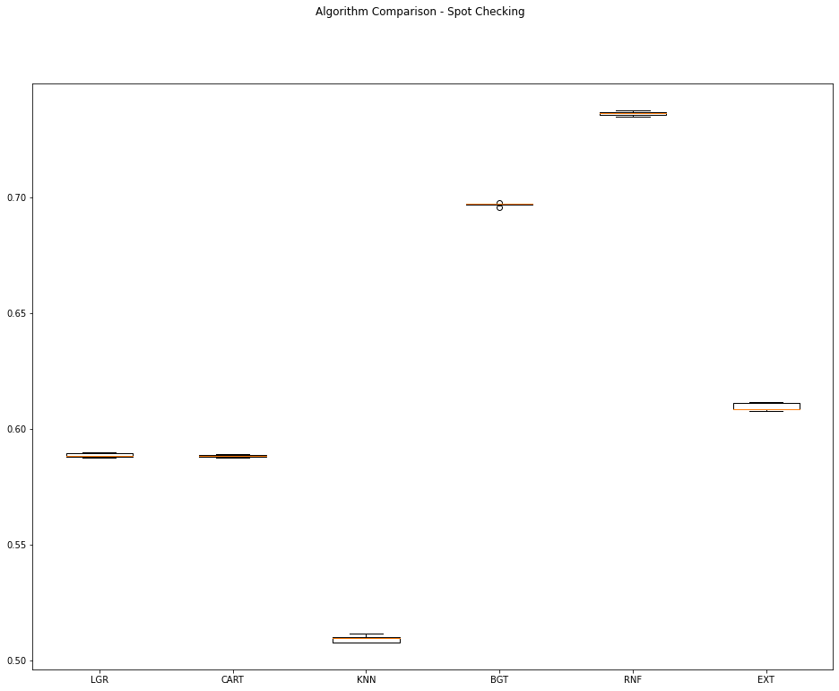

```python
fig = plt.figure(figsize=(16,12))
fig.suptitle('Algorithm Comparison - Spot Checking')
ax = fig.add_subplot(111)
plt.boxplot(train_results)
ax.set_xticklabels(train_model_names)
plt.show()
```

```python
if NOTIFY_STATUS: status_notify("Task 4 - Train and Evaluate Models completed! "+datetime.now().strftime('%a %B %d, %Y %I:%M:%S %p'))
```

## Task 5 - Fine-tune and Improve Models

```python
if NOTIFY_STATUS: status_notify("Task 5 - Fine-tune and Improve Models has begun! "+datetime.now().strftime('%a %B %d, %Y %I:%M:%S %p'))
```

### 5.a) Algorithm Tuning

```python
# Not applicable for this iteration of the project
```

### 5.b) Compare Algorithms After Tuning

```python
# Not applicable for this iteration of the project
```

```python
if NOTIFY_STATUS: status_notify("Task 5 - Fine-tune and Improve Models completed! "+datetime.now().strftime('%a %B %d, %Y %I:%M:%S %p'))
```

## Task 6 - Finalize Model and Present Analysis

```python
if NOTIFY_STATUS: status_notify("Task 6 - Finalize Model and Present Analysis has begun! "+datetime.now().strftime('%a %B %d, %Y %I:%M:%S %p'))
```

### 6.a) Train the Final Model

```python
final_model = RandomForestClassifier(random_state=RNG_SEED, n_jobs=N_JOBS)
final_model.fit(array_features_train, array_target_train)
print(final_model)
```

```
RandomForestClassifier(n_jobs=1, random_state=888)
```

### 6.b) Load Test Dataset and Prepare the Submission File

```python
dataset_path = 'https://dainesanalytics.com/datasets/kaggle-tabular-playground-2021sep/test.csv'
df_features_test = pd.read_csv(dataset_path, index_col=False)

# Take a peek at the dataframe after import
print(df_features_test.head())
```

```
       id        f1        f2        f3       f4       f5       f6       f7  \
0  957919  0.165850  0.487050   1295.00  0.02310  0.31900  0.90188   573.29
1  957920  0.129650  0.373480   1763.00  0.72884  0.33247 -1.26310   875.55
2  957921  0.120190  0.445210    736.26  0.04615  0.29605  0.31665  2659.50
3  957922  0.054008  0.395960    996.14  0.85934  0.36678 -0.17060   386.56
4  957923  0.079947 -0.006919  10574.00  0.34845  0.45008 -1.84200  3027.00

         f8            f9  ...     f109     f110    f111      f112     f113  \
0    3743.7  2.705700e+12  ...  0.16253 -22.1890  2.0655  0.430880 -10.7410
1  554370.0  5.955700e+14  ...  0.81528  -1.6342  1.5736 -1.071200  11.8320
2  317140.0  3.977800e+14  ...  0.81831 -32.7800  2.1364 -1.931200  -3.2804
3  325680.0 -3.432200e+13  ...  0.86559  -2.4162  1.5199 -0.011633   1.3840
4  428150.0  9.291500e+11  ...  0.25190 -18.6300  3.7387  0.757080  -4.9405

      f114    f115          f116    f117     f118
0  81606.0  1.1940  1.980400e+14  2017.1  0.46357
1  90114.0  1.1507  4.388000e+16  6638.9  0.28125
2  37739.0  1.1548  1.718100e+14  5844.0  0.13797
3  26849.0  1.1490  2.138800e+17  6173.3  0.32910
4  50336.0  1.2488  2.151300e+17  2250.1  0.33796

[5 rows x 119 columns]
```

```python
df_kaggle_submission = pd.DataFrame()
df_kaggle_submission['id'] = df_features_test['id']
print(df_kaggle_submission.head())
```

```
       id
0  957919
1  957920
2  957921
3  957922
4  957923
```

```python
# Dropping features
df_features_test.drop(columns=['id'], inplace=True)

# Take a peek at the dataframe after cleaning
print(df_features_test.head())
```

```
         f1        f2        f3       f4       f5       f6       f7        f8  \
0  0.165850  0.487050   1295.00  0.02310  0.31900  0.90188   573.29    3743.7
1  0.129650  0.373480   1763.00  0.72884  0.33247 -1.26310   875.55  554370.0
2  0.120190  0.445210    736.26  0.04615  0.29605  0.31665  2659.50  317140.0
3  0.054008  0.395960    996.14  0.85934  0.36678 -0.17060   386.56  325680.0
4  0.079947 -0.006919  10574.00  0.34845  0.45008 -1.84200  3027.00  428150.0

             f9       f10  ...     f109     f110    f111      f112     f113  \
0  2.705700e+12  6221.000  ...  0.16253 -22.1890  2.0655  0.430880 -10.7410
1  5.955700e+14   934.430  ...  0.81528  -1.6342  1.5736 -1.071200  11.8320
2  3.977800e+14   131.810  ...  0.81831 -32.7800  2.1364 -1.931200  -3.2804
3 -3.432200e+13   -26.473  ...  0.86559  -2.4162  1.5199 -0.011633   1.3840
4  9.291500e+11  5999.400  ...  0.25190 -18.6300  3.7387  0.757080  -4.9405

      f114    f115          f116    f117     f118
0  81606.0  1.1940  1.980400e+14  2017.1  0.46357
1  90114.0  1.1507  4.388000e+16  6638.9  0.28125
2  37739.0  1.1548  1.718100e+14  5844.0  0.13797
3  26849.0  1.1490  2.138800e+17  6173.3  0.32910
4  50336.0  1.2488  2.151300e+17  2250.1  0.33796

[5 rows x 118 columns]
```

```python
# Finalize the test dataset for the modeling testing
array_features_test = preprocessor.transform(df_features_test)
print("Transformed features from df_features_test.shape: {} to array_features_test.shape: {}".format(df_features_test.shape, array_features_test.shape))
```

```
Transformed features from df_features_test.shape: (493474, 118) to array_features_test.shape: (493474, 118)
```

```python
# Make batched predictions
test_predictions = final_model.predict_proba(array_features_test)[:,1]
print(test_predictions)
```

```
[0.24 0.27 0.65 ... 0.82 0.37 0.67]
```

```python
df_kaggle_submission['claim'] = test_predictions
print(df_kaggle_submission.head())
```

```
       id  claim
0  957919   0.24
1  957920   0.27
2  957921   0.65
3  957922   0.35
4  957923   0.32
```

```python
submission_file = df_kaggle_submission.to_csv(header=True, index=False)
filename = 'submission_' + datetime.now().strftime('%Y%m%d-%H%M') + '.csv'
with open(filename, 'w') as f:
    f.write(submission_file)
    print('Completed writing output file: ' + filename)
```

```
Completed writing output file: submission_20211017-0628.csv
```

```python
if NOTIFY_STATUS: status_notify("Task 6 - Finalize Model and Present Analysis completed! "+datetime.now().strftime('%a %B %d, %Y %I:%M:%S %p'))
```

```python
print ('Total time for the script:',(datetime.now() - start_time_script))
```

```
Total time for the script: 2 days, 5:55:36.769751
```